# Trabalho Prático - Extração de Conhecimento de Dados Biológicos

Diogo Barreira, Gonçalo Gomes, José Campos

2026-04-21

# 1. Introdução

Os dados utilizados para o desenvolvimento do trabalho prático são provenientes do “The Cancer Genome Atlas” (TCGA), mais concretamente referentes ao carcinoma da tiróide (THCA) e foram consultados através do portal do National Cancer Institute. A escolha desta base de dados justifica-se pelo cancro da tiróide ser uma neoplasia endócrina muito comum (Wang et al., 2017; Du et al., 2021). Os autores acrescentam ainda que apesar de tipicamente os prognósticos serem bons, uma parte dos casos apresenta um comportamento muito agressivo. O TCGA-THCA permitiu que fossem identificados subtipos moleculares importantes, tais como perfis BRAF-like e RAS-like essenciais para a medicina de precisão (The Cancer Genome Atlas Research Network, 2014).

# 2. Os Dados

Os dados utilizados foram obtidos através do pacote TCGAbiolinks, que permite aceder diretamente ao repositório Genomic Data Commons (GDC).

- **Projeto:** TCGA-THCA
- **Tipo de dados:** expressão génica (RNA-Seq)
- **Formato:** contagens de leitura por gene

Estes dados são relevantes porque permitem comparar a expressão génica entre tumores e tecidos normais, possibilitando a identificação de genes associados ao desenvolvimento do cancro.

# 3. Carregamento e preparação dos dados

```r
library(SummarizedExperiment)
library(DESeq2)
library(pheatmap)
library(clusterProfiler)
library(org.Hs.eg.db)
```

```r
# Carregar dados previamente obtidos e guardados no final da fase 1 com saveRDS()
# Garante que o ficheiro está na mesma pasta que este .Rmd, ou ajusta o caminho
data_thca <- readRDS("dados_thca.rds")

exp_matrix <- assay(data_thca)
# As linhas representam genes e as colunas representam amostras.
```

## 3.1 Dimensões do dataset

```r
cat("Dimensões antes da filtragem:", dim(exp_matrix), "\n")
```

```
## Dimensões antes da filtragem: 60660 572
```

# 4. Pré-processamento dos dados

## 4.1 Filtragem de genes pouco expressos

```r
keep         <- rowSums(exp_matrix > 10) >= 10
exp_filtered <- exp_matrix[keep, ]
# Remoção dos genes de baixa expressão.
```

## 4.2 Dimensões após filtragem

```r
cat("Dimensões após filtragem:", dim(exp_filtered), "\n")
```

```
## Dimensões após filtragem: 28300 572
```

## 4.3 Transformação logarítmica

```r
exp_log <- log2(exp_filtered + 1)
# Transformação log2 para estabilizar a variância e tornar os dados
# mais adequados para análise estatística exploratória.
```

# 5. Análise exploratória e estatística descritiva

## 5.1 Estatísticas básicas

```r
# Resumo das primeiras 5 amostras para não sobrecarregar o output
summary(exp_log[, 1:5])
```

```
##  TCGA-DJ-A2Q6-01A-11R-A18C-07 TCGA-FK-A3SE-01A-11R-A22L-07
##  Min.   : 0.000               Min.   : 0.000
##  1st Qu.: 3.700               1st Qu.: 3.322
##  Median : 7.229               Median : 6.931
##  Mean   : 7.376               Mean   : 7.120
##  3rd Qu.:11.163               3rd Qu.:10.965
##  Max.   :21.023               Max.   :21.036
##  TCGA-DJ-A2QA-01A-11R-A18C-07 TCGA-FY-A2QD-01A-11R-A19O-07
##  Min.   : 0.000               Min.   : 0.000
##  1st Qu.: 2.000               1st Qu.: 2.585
##  Median : 5.644               Median : 6.109
##  Mean   : 5.779               Mean   : 6.443
##  3rd Qu.: 9.484               3rd Qu.:10.424
##  Max.   :21.245               Max.   :22.013
##  TCGA-EL-A3GR-01A-21R-A206-07
##  Min.   : 0.000
##  1st Qu.: 3.170
##  Median : 6.524
##  Mean   : 6.743
##  3rd Qu.:10.396
##  Max.   :19.919
```

## 5.2 Visualização da distribuição

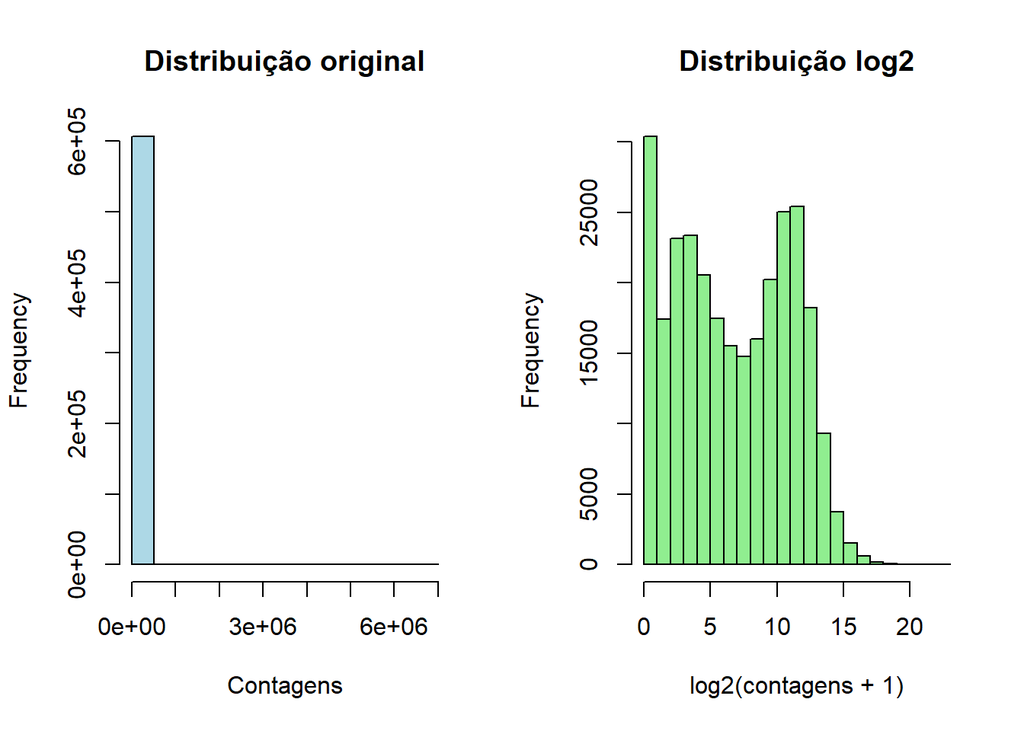

```r
par(mfrow = c(1, 2))
hist(as.numeric(exp_matrix[, 1:10]),
     main = "Distribuição original", col = "lightblue",  xlab = "Contagens")
hist(as.numeric(exp_log[, 1:10]),
     main = "Distribuição log2",     col = "lightgreen", xlab = "log2(contagens + 1)")
```

```r
par(mfrow = c(1, 1))
# A logaritmização reduz a assimetria da distribuição.
```

## 5.3 Boxplot das amostras

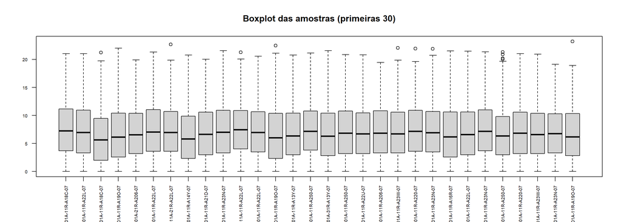

```r
boxplot(exp_log[, 1:30],
        main     = "Boxplot das amostras (primeiras 30)",
        las      = 2,
        cex.axis = 0.6)
```

```r
# Permite identificar diferenças entre amostras e possíveis outliers.
```

## 5.4 Heatmap dos genes mais variáveis

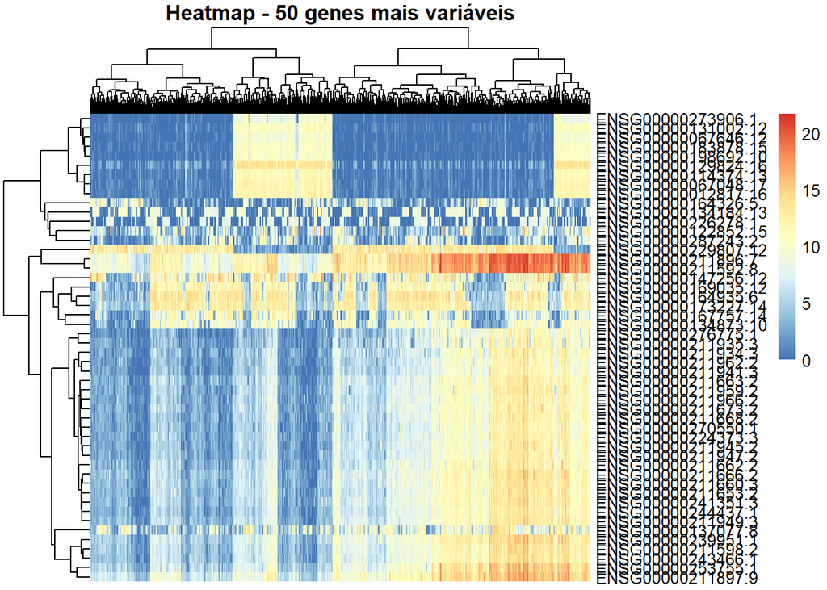

```r
var_genes     <- apply(exp_log, 1, var)
top_var_genes <- names(sort(var_genes, decreasing = TRUE))[1:50]

pheatmap(exp_log[top_var_genes, ],
         show_colnames = FALSE,
         main          = "Heatmap - 50 genes mais variáveis")
```

# 6. Definição dos grupos

```r
group <- ifelse(substr(colnames(exp_log), 14, 15) == "01", "Tumor", "Normal")
group <- factor(group)
table(group)
```

```
## group
## Normal  Tumor
##     67    505
```

As amostras são classificadas como **Tumor** ou **Normal** com base nas posições 14-15 do barcode TCGA.

## 6.1 PCA das amostras

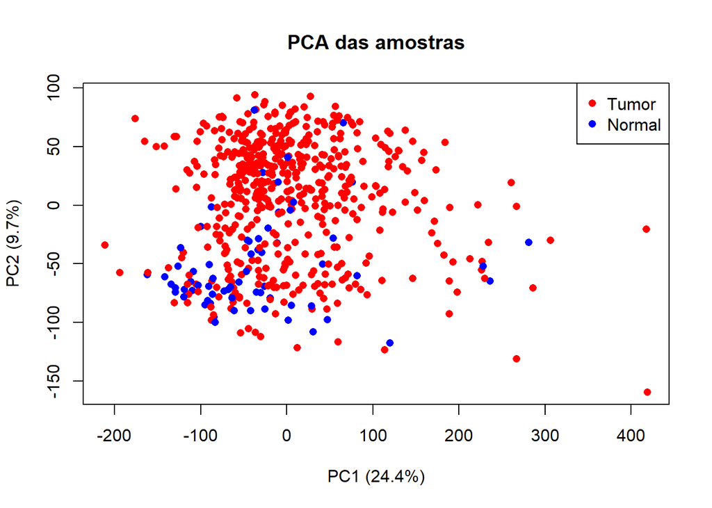

```r
pca <- prcomp(t(exp_log), scale. = TRUE)

plot(pca$x[, 1], pca$x[, 2],
     col  = ifelse(group == "Tumor", "red", "blue"),
     pch  = 16,
     xlab = paste0("PC1 (", round(summary(pca)$importance[2, 1] * 100, 1), "%)"),
     ylab = paste0("PC2 (", round(summary(pca)$importance[2, 2] * 100, 1), "%)"),
     main = "PCA das amostras")
legend("topright", legend = c("Tumor", "Normal"), col = c("red", "blue"), pch = 16)
```

# 7. Análise de expressão diferencial

## 7.1 Preparação dos dados para DESeq2

```r
# DESeq2 exige contagens inteiras — usa exp_filtered (não log2)
coldata <- data.frame(
  row.names = colnames(exp_filtered),
  condition = group
)

dds <- DESeqDataSetFromMatrix(
  countData = round(exp_filtered),  # arredondar para garantir inteiros
  colData   = coldata,
  design    = ~ condition
)

dds <- DESeq(dds)
```

```r
# Transformação VSD para análises downstream (clustering, heatmaps)
vsd     <- varianceStabilizingTransformation(dds, blind = FALSE)
exp_vsd <- assay(vsd)
```

## 7.2 Resultados e contagem de DEGs

```r
res        <- results(dds, contrast = c("condition", "Tumor", "Normal"))
resOrdered <- res[order(res$padj), ]

n_sig <- sum(res$padj < 0.05, na.rm = TRUE)
cat("Genes diferencialmente expressos (FDR < 0.05):", n_sig, "\n")
```

```
## Genes diferencialmente expressos (FDR < 0.05): 18598
```

## 7.3 MA plot e Volcano plot

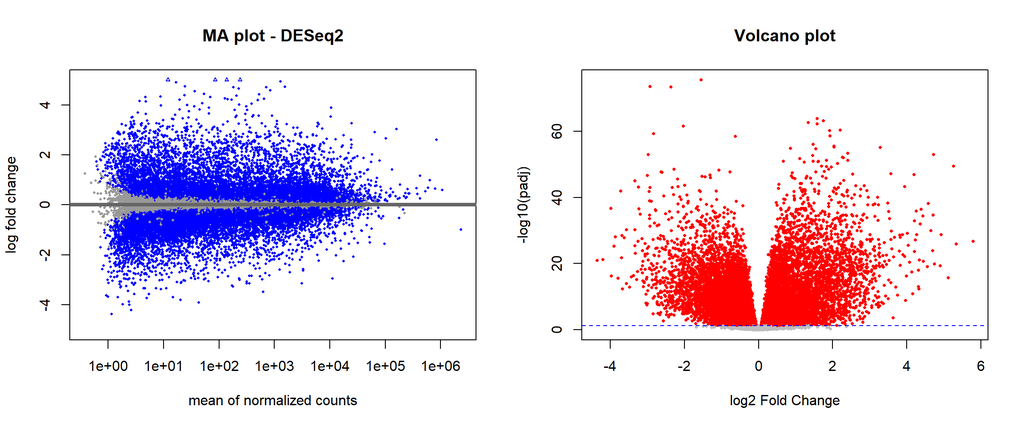

```r
par(mfrow = c(1, 2))

# MA plot
plotMA(res, main = "MA plot - DESeq2", ylim = c(-5, 5))

# Volcano plot — variáveis extraídas dos resultados DESeq2
logFC <- res$log2FoldChange
pval  <- res$padj

plot(logFC, -log10(pval),
     pch  = 16, cex = 0.5,
     col  = ifelse(!is.na(pval) & pval < 0.05, "red", "grey"),
     xlab = "log2 Fold Change",
     ylab = "-log10(padj)",
     main = "Volcano plot")
abline(h = -log10(0.05), col = "blue", lty = 2)
```

```r
par(mfrow = c(1, 1))
```

A análise de expressão diferencial foi realizada com o pacote DESeq2, que modela diretamente dados de contagem utilizando uma distribuição binomial negativa, permitindo uma estimativa robusta da variabilidade entre amostras. Foram identificados genes diferencialmente expressos entre tumor e normal (FDR < 0.05). O MA plot e o volcano plot permitem observar a magnitude das alterações de expressão e a sua significância estatística.

## 7.4 Tabela top DEGs

```r
top_degs <- as.data.frame(
  resOrdered[!is.na(resOrdered$padj) & resOrdered$padj < 0.05, ]
)
head(top_degs[order(top_degs$padj), c("log2FoldChange", "padj")], 20)
```

```
##                    log2FoldChange         padj
## ENSG00000100784.12     -1.5614555 3.078381e-76
## ENSG00000271367.1      -2.9337961 2.858515e-74
## ENSG00000279602.1      -2.3771107 3.439966e-74
## ENSG00000072682.19      1.5748449 1.247830e-64
## ENSG00000204131.9       1.7385246 6.691721e-64
## ENSG00000004399.13      1.3304310 2.020752e-63
## ENSG00000172667.11      1.5730781 4.790478e-63
## ENSG00000128536.16     -2.0306967 2.986139e-62
## ENSG00000169302.16      2.1970055 4.788197e-61
## ENSG00000107731.12      1.9122244 5.227816e-61
## ENSG00000133800.9      -2.8350099 5.486167e-60
## ENSG00000149573.9       1.9261592 2.717947e-59
## ENSG00000169762.17     -0.6345722 3.649369e-59
## ENSG00000260912.1       1.4652764 7.226361e-57
## ENSG00000163235.16      2.0363365 2.898927e-56
## ENSG00000158352.16      2.0362851 5.038799e-56
## ENSG00000130513.6       3.2827590 7.275099e-56
## ENSG00000197183.14      0.8603586 1.327772e-55
## ENSG00000110092.4       1.5381823 1.979043e-55
## ENSG00000244694.7       2.3997243 4.176280e-54
```

# 8. Análise de enriquecimento funcional

```r
# Genes significativos
sig_genes   <- rownames(res)[!is.na(res$padj) & res$padj < 0.05]
genes_clean <- sub("\\..*", "", sig_genes)  # remover sufixos de versão ENSEMBL
head(genes_clean)
```

```
## [1] "ENSG00000000005" "ENSG00000000419" "ENSG00000000457" "ENSG00000000460"
## [5] "ENSG00000001036" "ENSG00000001084"
```

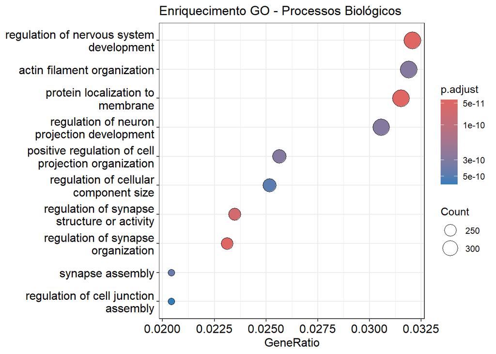

```r
entrez_ids <- bitr(
  genes_clean,
  fromType = "ENSEMBL",
  toType   = "ENTREZID",
  OrgDb    = org.Hs.eg.db
)

ego <- enrichGO(
  gene          = entrez_ids$ENTREZID,
  OrgDb         = org.Hs.eg.db,
  ont           = "BP",
  pAdjustMethod = "BH",
  pvalueCutoff  = 0.05
)

dotplot(ego, showCategory = 10, title = "Enriquecimento GO - Processos Biológicos")
```

Foi necessário converter os identificadores ENSEMBL para ENTREZID e remover sufixos de versão, uma vez que ferramentas de enriquecimento funcional requerem formatos específicos de identificação génica. É esperado que uma fração dos genes não seja convertida devido a limitações nas bases de dados e diferenças na anotação génica.

# 9. Análise não supervisionada

## 9.1 Clustering hierárquico das amostras

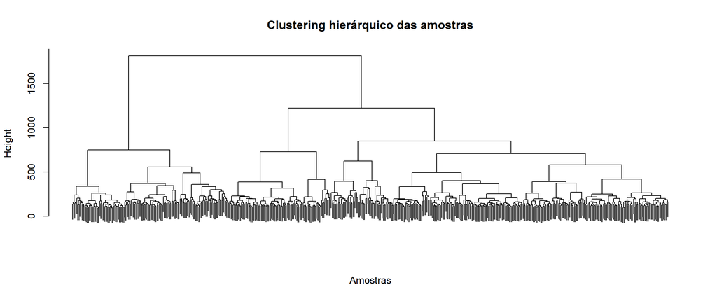

```r
dist_mat <- dist(t(exp_vsd))
hc       <- hclust(dist_mat, method = "ward.D2")

plot(hc,
     main   = "Clustering hierárquico das amostras",
     labels = FALSE,
     xlab   = "Amostras",
     sub    = "")
```

```r
clusters <- cutree(hc, k = 2)
cat("\nCorrespondência clusters vs grupos biológicos:\n")
```

```
##
## Correspondência clusters vs grupos biológicos:
```

```r
print(table(Cluster = clusters, Grupo = group))
```

```
##        Grupo
## Cluster Normal Tumor
##       1     26   396
##       2     41   109
```

## 9.2 Heatmap com anotação de grupos

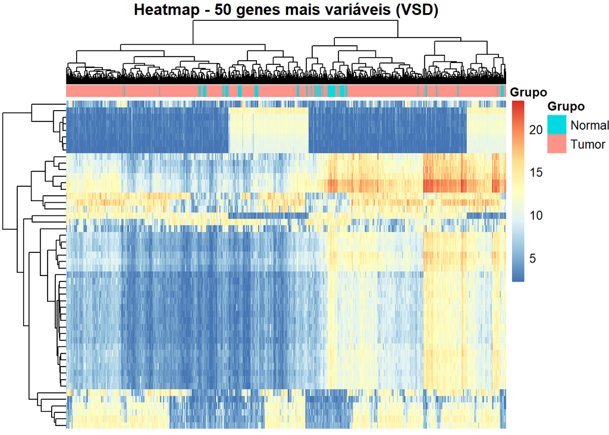

```r
var_genes_vsd <- apply(exp_vsd, 1, var)
top_genes     <- names(sort(var_genes_vsd, decreasing = TRUE))[1:50]

annotation <- data.frame(Grupo = group)
rownames(annotation) <- colnames(exp_vsd)

pheatmap(exp_vsd[top_genes, ],
         annotation_col = annotation,
         show_rownames  = FALSE,
         show_colnames  = FALSE,
         main           = "Heatmap - 50 genes mais variáveis (VSD)")
```

O heatmap permite visualizar padrões de expressão génica nos 50 genes mais variáveis e verificar a separação entre os grupos de amostras. A anotação por cor facilita a identificação visual dos grupos tumorais e normais.

## 9.3 MDS (Multidimensional Scaling)

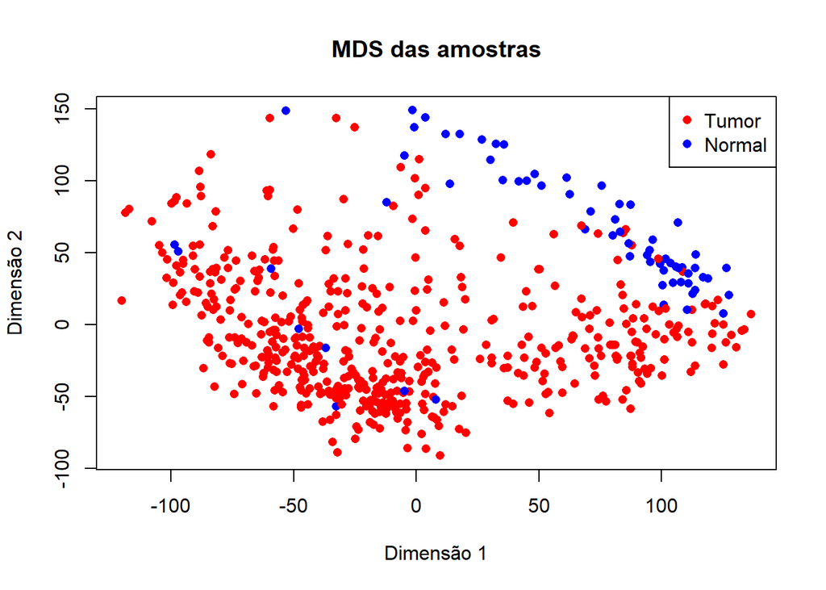

```r
mds <- cmdscale(dist_mat, k = 2)

plot(mds[, 1], mds[, 2],
     col  = ifelse(group == "Tumor", "red", "blue"),
     pch  = 16,
     xlab = "Dimensão 1",
     ylab = "Dimensão 2",
     main = "MDS das amostras")
legend("topright", legend = c("Tumor", "Normal"), col = c("red", "blue"), pch = 16)
```

O MDS é uma técnica de redução de dimensionalidade que preserva as distâncias entre amostras no espaço original. Tal como na PCA, observa-se uma separação entre amostras tumorais e normais, confirmando a existência de perfis de expressão génica distintos entre os dois grupos.